# Lab 8a

GAO Zheng

November 2, 2016

## News Flash: Rstudio got updated

Check it out [here](https://blog.rstudio.org/2016/11/01/announcing-rstudio-v1-0/).

Now you can download the RMarkdown file by clicking the button in the rupper right corner of this html page.

## Law of Large Numbers

Write a function which calculates the empirical distribution function of $X_1,\cdots,X_m\stackrel{\text{iid}}{\sim}N(0,1)$. The empirical distribution function is defined as
$$\Phi_m(x) = \frac{1}{m}\sum_{i=1}^mI(X_i\leq x)$$
where $I(X\leq x)$ is an indicator function, taking value 1 if $X\leq x$ and 0 otherwise. Plot this function for $x\in[-4,4]$. Let $m=5, 50, 500$ respectively and plot all three empirical CDF’s on the same figure, with the true standard Normal cdf superimposed for comparison.

```r
Phi.m = function(m,xseq){
    # xseq can be either a scalar or a vector
    X = rnorm(m)
    Phi.m.x = sapply(xseq,function(x){mean(X<x)})
    return(Phi.m.x)
}
m = c(5,50,500)
xseq = seq(-4,4,by=0.01)
plot(0,xlim=c(-4,4),ylim=c(0,1),xlab="x",ylab="Phi.m(x)",
     main="Empirical CDF", type='n')
for (i in 1:length(m)){
    par(new=T)
    plot(xseq,Phi.m(m[i],xseq),col=i,axes=F,type="l",xlim=c(-4,4),
    ylim=c(0,1),xlab="",ylab="")
}
```

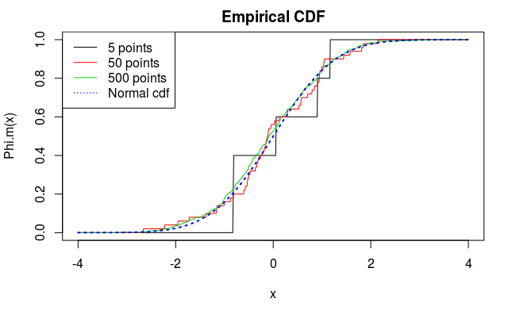

```r
lines(xseq,pnorm(xseq,mean=0,sd=1),col=4,lty=3,lwd=2)
legend("topleft",legend=c(paste(m,'points'),'Normal cdf'),
       col=1:4,lty=c(1,1,1,3))
```

**Remark**: here for almost all $x$, the value $\Phi_m(x)$ is approaching the Normal cdf. Why does this happen? Recall the Law of Large Numbers: for any fixed $x$, $\Phi_m(x)$ is the mean of $m$ independent identically distributed random variables $I(X_i\leq x)$, therefore it will converge to the expectation $E(I(X_1\leq x))=P(X_{1}\leq x)$, which is the standard Normal cdf.

In other words, the empirical cdf converges point-wise to the true cdf

## Generating random variables with inversion method and more

Random variables from a particular distribution can be generated through uniform random variables by inverting their cumulative distribution function (cdf). That is, if you create i.i.d. samples $U_1, \cdots , U_n$ from $\textrm{Uniform}(0, 1)$ distribution and compute $F^{-1}(U_1), \cdots , F^{-1}(U_n)$ (assuming it is well-defined), then what you get is samples from a distribution with cdf $F$ . Using this property, we’ll generate exponential random variables and gamma random variables.

*(a)*

The Exponential$(\lambda)$ distribution has cdf

$$F(x) = 1 - e^{-\lambda x}, \lambda > 0$$
Using `runif` function, generate 100 samples from `Exponential(3)` distribution using the inversion method. Graph the density histogram for the sample with the true density superimposed for comparison.

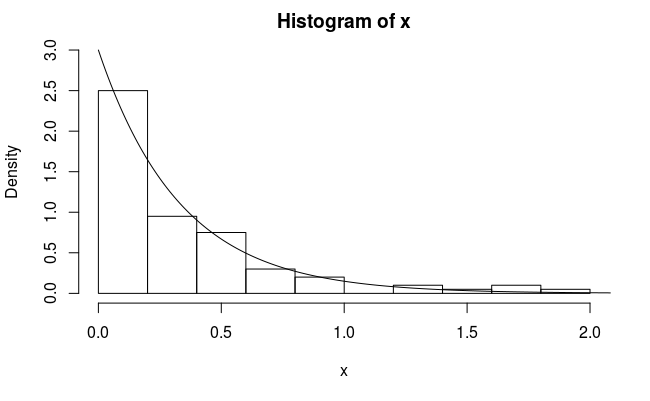

```r
n = 100
lambda = 3
x = -(1/lambda)*log(runif(n))
hist(x, prob = TRUE, ylim = c(0,3))
y = seq(0,10,length = 1000)
lines(y,dexp(y,3))
```

*(b)*

$\textrm{Gamma}(k, \theta)~,~k>0,~\theta>0$ distribution has density:

$$f(x) = \frac{\theta^k}{(k-1)!}x^{k-1}e^{-\theta x}$$
where $k~and~\theta$ are shape and rate parameters.

The exponential distribution with parameter $\lambda$ is a special case of of Gamma distribution.

**Q:** What are $k$ and $\theta$ for an Exponential($\lambda$)in the Gamma distribution?

Gamma distribution also has the property that if $X \sim Gamma(a, \theta)$ and $Y \sim Gamma(b, \theta)$, and $X$ and $Y$ are independent, then
$$X+Y \sim Gamma(a+b,\theta).$$
Using this property and the way to generate exponential distributions, create 10 samples from Gamma(5, 3) distribution.

```r
n = 10
k = 5
lambda = 3
x = matrix(-(1/lambda)*log(runif(n*k)), ncol=k)
(g = apply(x, 1, sum))
```

```
 [1] 2.9661381 2.7363221 2.0218642 1.6841951 1.1166063 0.7739007 1.4714379 1.7460951
 [9] 2.4816702 1.4567746
```

**Remark**: the density of exponential distribution is $\lambda e^{-\lambda x}$, which you can derive by taking the derivative of the cdf. Comparing with Gamma density, we see here $\theta=\lambda$ and $k=1$. We simulated the Gamma(5,3) as the sum of 5 independent exponential variables with $\lambda=3$.

## Inversion method for discrete random variables

Write a function to generate $n$ random numbers from binomial distribution with $m$ trials and $p$ using inversion sampling. The mass function of binomial distribution is
$$P(X=k)= {m \choose k} p^k (1-p)^{m-k}$$
where $k = 0,1,\ldots,m$. We set $n = 1000$, $p = 0.4$. Plot the histogram with $m = 10$.

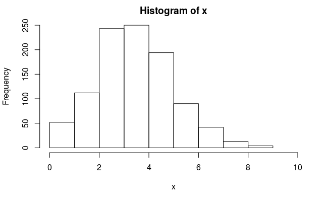

```r
## Function to implement the inversion sampling
## for binomial distribution
binomial <- function(n, n_max, prob)
{
  ## Generate n uninform numbers
  z <- runif(n)
  ## Obtain P(X=0), P(X=1), ..., P(X=num_trails)
  k = seq(0, n_max)
  p <- choose(n_max, k)* prob^k * (1-prob)^(n_max-k)
  ## Intialize the binomial numbers
  x <- rep(0, n)
  for (i in seq(1, n))
  {
    s <- 0  ## Initialize the sum
    t <- -1  ## Initialize
    ## While loop
    ## Finding the smallest k such that p[1]+...p[t] > z[i]
    while (s < z[i])
    {
      t <- t + 1
      s <- s + p[t+1]
    }
    x[i] <- t
  }

  return(x)
}
## Call binomial generator
x <- binomial(n = 1000, n_max = 10, prob = 0.4)
hist(x, xlim = c(0, 10))
```

c.f. the R base binomial random vairable generator

```r
x <- rbinom(n = 1000, size = 10, prob = 0.4)
hist(x, xlim = c(0, 10))
```

[output not shown]